# rawBeer

Autogenerated data summary from dataMaid

2018-10-15 11:32:50

# Data report overview

The dataset examined has the following dimensions:

| Feature | Result |
| --- | --- |
| Number of observations | 2410 |
| Number of variables | 7 |

### Checks performed

The following variable checks were performed, depending on the data type of each variable:

|  | character | factor | labelled | numeric | integer | logical | Date |
| --- | --- | --- | --- | --- | --- | --- | --- |
| Identify miscoded missing values | × | × | × | × | × |  |  |
| Identify prefixed and suffixed whitespace | × | × | × |  |  |  |  |
| Identify levels with < 6 obs. | × | × | × |  |  |  |  |
| Identify case issues | × | × | × |  |  |  |  |
| Identify misclassified numeric or integer variables | × | × | × |  |  |  |  |
| Identify outliers |  |  |  | × | × |  | × |

Please note that all numerical values in the following have been rounded to 2 decimals.

# Summary table

|  | Variable class | # unique values | Missing observations | Any problems? |
| --- | --- | --- | --- | --- |
| Name | character | 2305 | 0.00 % | × |
| Beer_ID | integer | 2410 | 0.00 % |  |
| ABV | numeric | 75 | 2.57 % | × |
| IBU | integer | 108 | 41.70 % |  |
| Brewery_id | integer | 558 | 0.00 % |  |
| Style | character | 100 | 0.00 % | × |
| Ounces | numeric | 7 | 0.00 % | × |

# Variable list

## Name

| Feature | Result |
| --- | --- |
| Variable type | character |
| Number of missing obs. | 0 (0 %) |
| Number of unique values | 2305 |
| Mode | “Nonstop Hef Hop” |

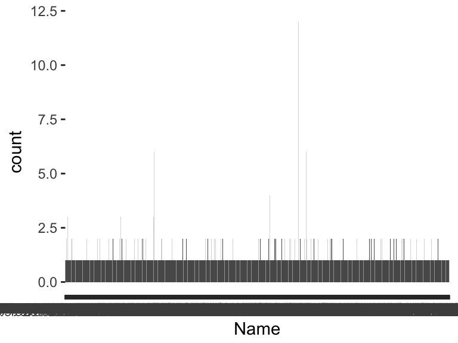

- The following values appear with prefixed or suffixed white space: "14° ESB ", "32°/50° Kölsch ", "Alter Ego ", "Aurora ", "Bunker Hill Blueberry Ale ", "Lewbricator Wheat Dopplebock ", "Nordskye ", "Port Barrel Wee Mac ", "Texicali ", "White Rabbit ".
- Note that the following levels have at most five observations: "#001 Golden Amber Lager", "#002 American I.P.A.", "#003 Brown & Robust Porter", "#004 Session I.P.A.", "#9", "077XX", "10 Degrees of Separation", "10 Ton", "113 IPA", "11th Hour IPA" (2292 additional values omitted).

## Beer_ID

| Feature | Result |
| --- | --- |
| Variable type | integer |
| Number of missing obs. | 0 (0 %) |
| Number of unique values | 2410 |
| Median | 1453.5 |
| 1st and 3rd quartiles | 808.25; 2075.75 |
| Min. and max. | 1; 2692 |

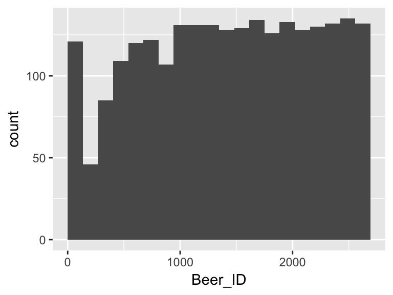

## ABV

| Feature | Result |
| --- | --- |
| Variable type | numeric |
| Number of missing obs. | 62 (2.57 %) |
| Number of unique values | 74 |
| Median | 0.06 |
| 1st and 3rd quartiles | 0.05; 0.07 |
| Min. and max. | 0; 0.13 |

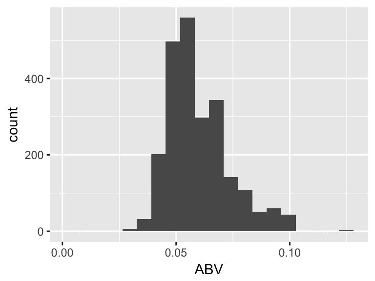

- Note that the following possible outlier values were detected: "0", "0.03", "0.03", "0.03", "0.03", "0.04", "0.04", "0.04", "0.04", "0.04" (3 additional values omitted).

## IBU

| Feature | Result |
| --- | --- |
| Variable type | integer |
| Number of missing obs. | 1005 (41.7 %) |
| Number of unique values | 107 |
| Median | 35 |
| 1st and 3rd quartiles | 21; 64 |
| Min. and max. | 4; 138 |

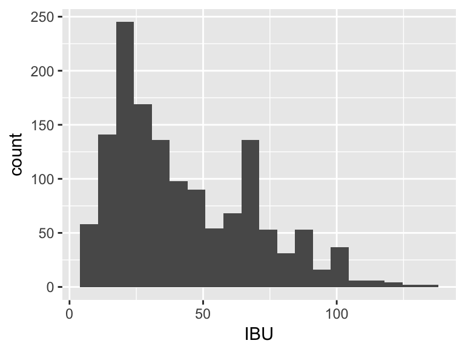

## Brewery_id

| Feature | Result |
| --- | --- |
| Variable type | integer |
| Number of missing obs. | 0 (0 %) |
| Number of unique values | 558 |
| Median | 206 |
| 1st and 3rd quartiles | 94; 367 |
| Min. and max. | 1; 558 |

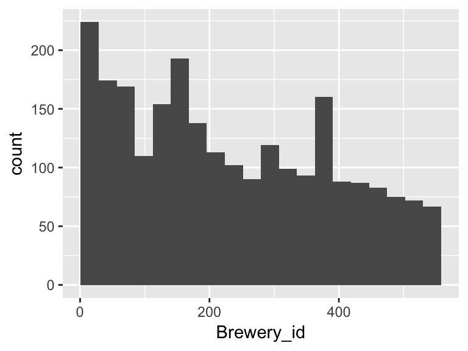

## Style

| Feature | Result |
| --- | --- |
| Variable type | character |
| Number of missing obs. | 0 (0 %) |
| Number of unique values | 100 |
| Mode | “American IPA” |

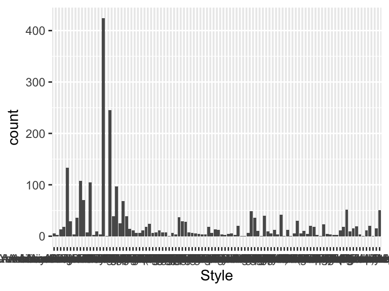

- The following suspected missing value codes enter as regular values: "".
- Note that the following levels have at most five observations: "", "Abbey Single Ale", "American Barleywine", "American Double / Imperial Pilsner", "American India Pale Lager", "American Malt Liquor", "Braggot", "Chile Beer", "Dubbel", "Dunkelweizen" (26 additional values omitted).

## Ounces

| Feature | Result |
| --- | --- |
| Variable type | numeric |
| Number of missing obs. | 0 (0 %) |
| Number of unique values | 7 |
| Median | 12 |
| 1st and 3rd quartiles | 12; 16 |
| Min. and max. | 8.4; 32 |

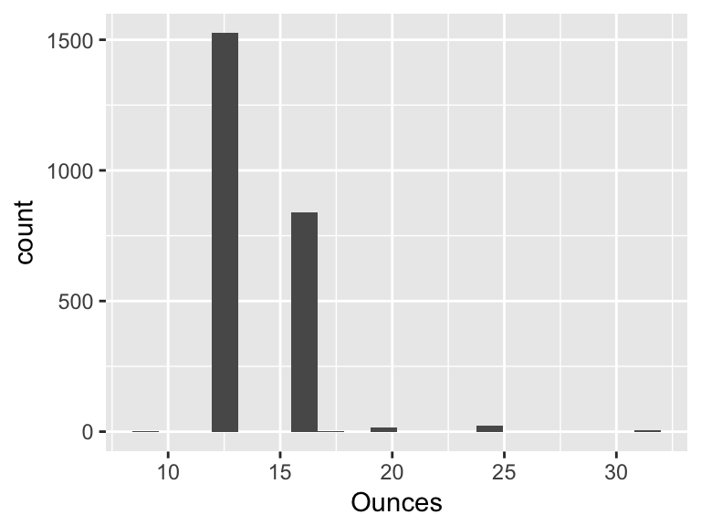

- Note that the following possible outlier values were detected: "8.4".

Report generation information:

- Created by Samantha Sprague.
- Report creation time: Mon Oct 15 2018 11:32:51
- dataMaid v1.0.0 [Pkg: 2017-11-10 from CRAN (R 3.3.2)]
- R version 3.3.3 (2017-03-06).
- Platform: x86_64-apple-darwin13.4.0 (64-bit)(macOS Sierra 10.12.6).
- Function call: `makeDataReport(data = rawBeer)`